# NFL Draft Quasi-Sharpe Ratio Analysis

How much is a draft pick really worth, by position?

Nick Gurol — [X/Twitter](https://x.com/run_the_sims) | [LinkedIn](https://www.linkedin.com/in/nick-gurol-87738a1b7/)

## Should a Team Love Love at #4 Overall?

Mock drafts have Jeremiah Love going as high as [**#4 overall**](https://grindingthemocks.shinyapps.io/Dashboard/). He’s been mocked to RB-needy teams like the Titans, Cardinals, Commanders, and Giants. These are all teams with top-10 picks that many would argue are not “a running back away.”

Analytic intuition says that spending premium draft capital on a “non-premium” position like RB is a horrible idea. On the other side, others cite Love’s elite prospect profile and the impact a running back like Saquon Barkley can have on a team’s Super Bowl run (see the [Eagles’ Super Bowl LIX victory in 2024](https://www.dazn.com/en-US/news/american-football/super-bowl-lix-saquon-barkley-breaks-nfl-record-to-as-philadelphia-eagles-dominate-kansas-city-chiefs-in-first-half/12vr71rrd1txd1em5r9hbxmqh3)).

In Part 1 of this series, I’ll lean more into the analytics side of things by empirically defining what a “hit” means while building my own version of a [Sharpe ratio](https://en.wikipedia.org/wiki/Sharpe_ratio), a risk-adjusted return metric originally used in finance to evaluate investments relative to their volatility. In Part 2, we’ll address some of the shortcomings of the Sharpe ratio to round out the argument about where exactly it makes sense to take a running back like Jeremiah Love. By the end of the series, hopefully there’s a better understanding of what it means to successfully make the leap from college to pros across all position groups, how the actual NFL market views different positions, and how different teams approach the NFL draft.

## The Setup

In the last few years, much has been made about the value of the running back position. [“Running backs don’t matter”](https://rbsdm.com/) has become a battle cry of sorts for the analytics community. The discourse on whether Jeremiah Love is worth a top-5 pick has [ignited weeks before the draft](https://x.com/minakimes/status/2041543125831926051?s=20).

Essentially, one side of the aisle says the market is the market and spending a premium pick on a running back doesn’t make sense given how cheap it is to find starter-level talent in free agency. The other says that truly elite talent has an on-field impact that the market and the nerds don’t understand because they didn’t play the game.

Let’s take a step back and first do our best to actually put some numbers to what the nerds are talking about. To quantify a few aspects of what it means to contribute to the NFL and what value the market places on different positions. To do that, we need to stand on the shoulders of giants.

- **Timo Riske’s hit rate methodology** ([PFF, 2022](https://www.pff.com/news/draft-what-historical-hit-rates-reveal-about-positional-success)): Riske defined what a draft “hit” means. A hit in his framework is a player whose snap share over their first 4 seasons exceeds a fraction of the positional baseline. I tighten his original 2/3 threshold to 75% to set a higher bar: this analysis cares about players who are on the field *more* than a replacement-level player during their rookie contract and play to a level where they earn a top-of-market second contract. Those thresholds are lofty, but they help us evaluate what kinds of players should be taken in the first round. Snap % is averaged over ALL expected games (including seasons not played as zero), so injuries and busts are properly penalized.
- **Brill & Wyner (2024)** ([arXiv:2407.00730](https://arxiv.org/abs/2407.00730), with analysis popularized by **Eric Eager** at PFF): Their key insight is that draft pick value is **nonlinear** and variance decays convexly across rounds, meaning earlier picks have fatter right tails. I operationalize this through the elite probability component of the Sharpe ratio: P(elite) captures the right-tail upside that a simple average would miss. Where Brill & Wyner measured upside through career approximate value, I extend it with cap-normalized contract data to make cross-era and cross-position comparisons possible, thereby capturing who the market deems as a truly valuable player.
- **Salary data** from [OverTheCap](https://overthecap.com/contracts) via [nflreadr](https://nflreadr.nflverse.com/). All contract values normalized to % of salary cap to control for cap inflation across eras.

My contribution is combining these frameworks into a single risk-adjusted metric (the quasi-Sharpe ratio) and adding two new dimensions: **rookie contract surplus** (the hidden majority of draft value) and **supply-controlled FA replacement** (because certain positions in high demand have fewer starting-level players available in free agency).

**Why 2022?** A fair evaluation requires at least 4 NFL seasons. Enough to complete a rookie deal and either earn a second contract or wash out. Players drafted after 2022 haven’t had that runway yet, so including them would bias results toward high rookie surplus and $0 second contracts. By stopping at 2022, every player in the dataset has had a real chance to prove (or not prove) their value.

## What Is a “Hit”?

Before building the Sharpe ratio, let’s first introduce the idea of a draft “hit” — the foundation everything else rests on. I classify a player as a “hit” if they play at least 75% as much as an established starter at their position over their first 4 NFL seasons. The threshold varies by position because not every position plays every snap:

| Position | What a starter plays | Hit threshold (75% of that) | What it means |
| --- | --- | --- | --- |
| IOL | ~100% of snaps | 75% | On the field nearly every play for 3+ years |
| OT | ~97% | 73% | Same — linemen don’t rotate |
| S | ~95% | 71% | Safeties play almost every defensive snap |
| LB / CB | ~92% | 69% | Occasionally rotate in sub packages |
| WR | ~85% | 64% | Come off in heavy sets and some run formations |
| QB | ~83% | 62% | Starters play every snap when healthy — injuries drive this down |
| EDGE | ~81% | 61% | Rotate with other pass rushers on some downs |
| DL | ~72% | 54% | Heavy rotation — even stars share snaps with the line |
| TE | ~71% | 53% | Many offenses rotate TEs situationally |
| RB | ~56% | 42% | Even a bellcow comes off for passing downs and in committee |

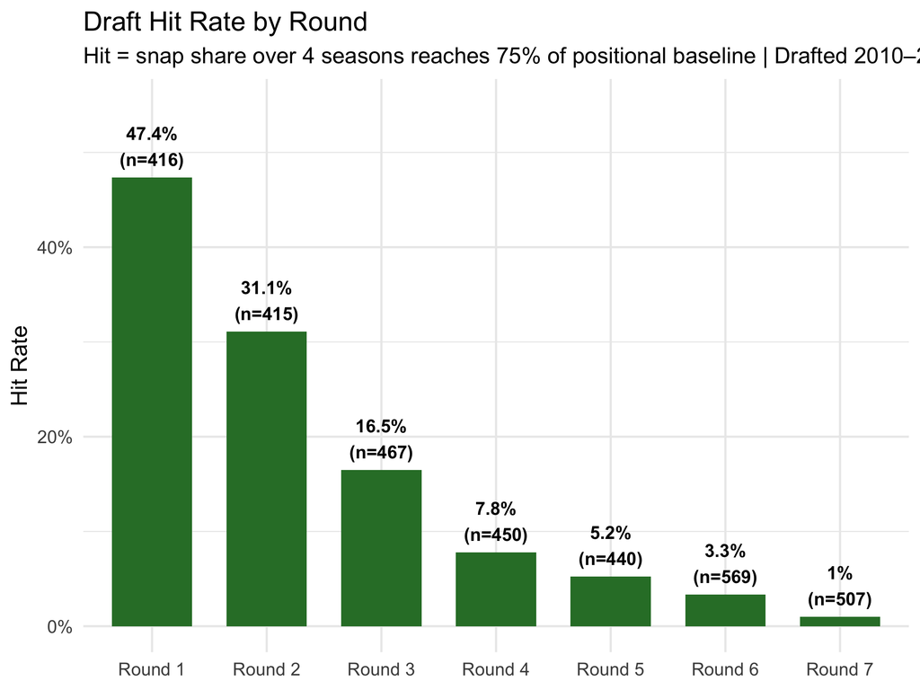

Breaking this down by position and tier reveals where the hits are concentrated:

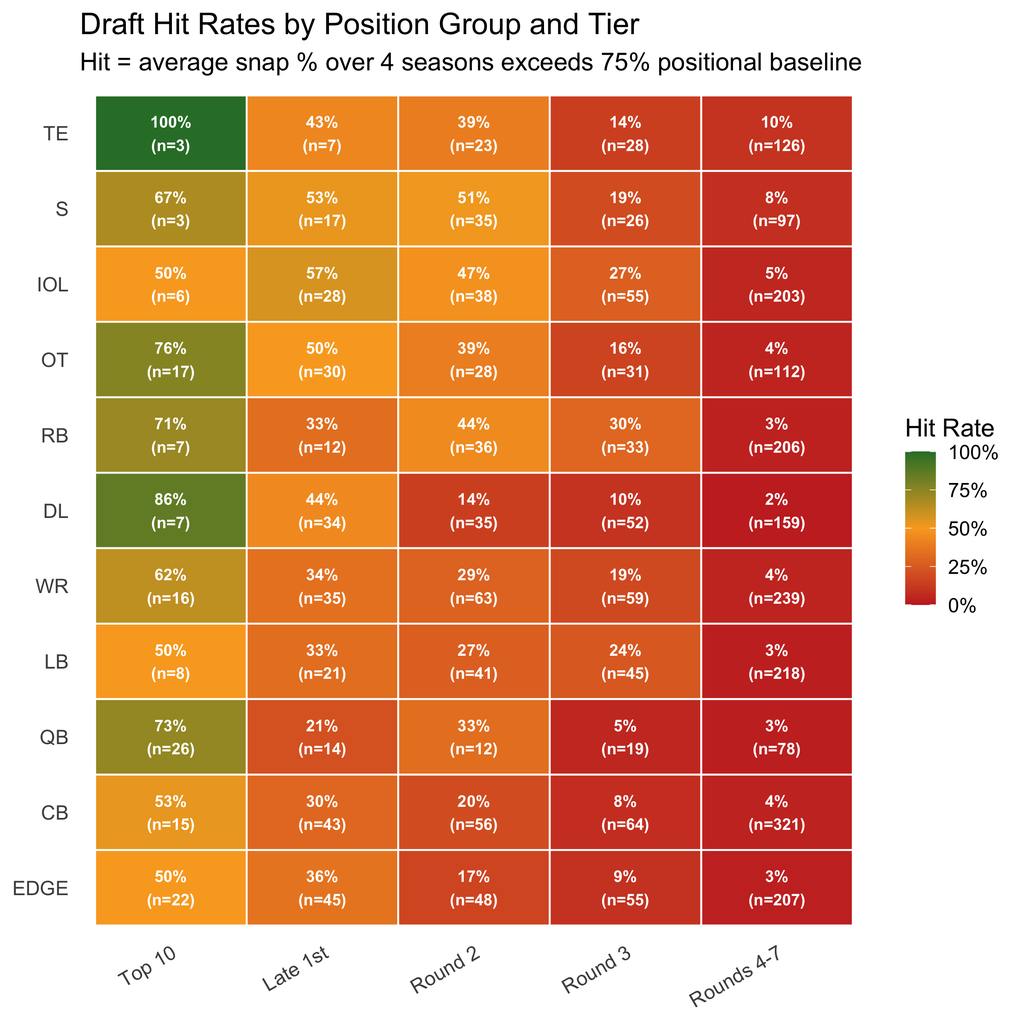

Look at the 5th round: a hit rate of just **5.2%**. That’s roughly one starter per decade per team. The draft’s late rounds are essentially lottery tickets.

[figure not shown]

Top 5 Teams by 5th-Round Hits

## The Draft Is the Best Path to Acquiring Elite Talent

Assuming the NFL free agency market is somewhat efficient, we can start to see some patterns in the supply and demand of what positions become available in free agency and what don’t. For positions that fetch the highest second contracts, the supply of reliable starting talent that hits free agency is lower than positions that fetch lower second contracts. This supply and demand dynamic is what drives the inequality across positions in the free agent market.

Only **3 starter-caliber OTs** and **3 QBs** hit free agency per year compared to **8 IOL**. When the supply of free agents is this low, the draft becomes the only reliable pipeline for building at that position.

How do we define “starter-caliber” here? I connect FA contracts back to the Riske hit methodology: first, identify drafted players who were hits (snap share ≥ 75% positional baseline over 4 seasons). Then look at what those hits earned on their second contracts and take the 25th percentile as a floor. If a free agent signs for at least that much, the market is telling us they’re starter-caliber. I count how many such contracts are signed per position per year (the **supply**, N), and the FA replacement cost is the median contract among those top-N signings each year.

This is why the Sharpe ratio penalizes RB so heavily and rewards QB and OT: when a position has an abundant free agency market, the “just sign a free agent” alternative is cheap and realistic. When it doesn’t, the draft is the only game in town, and that scarcity drives up the value of getting it right with a draft pick.

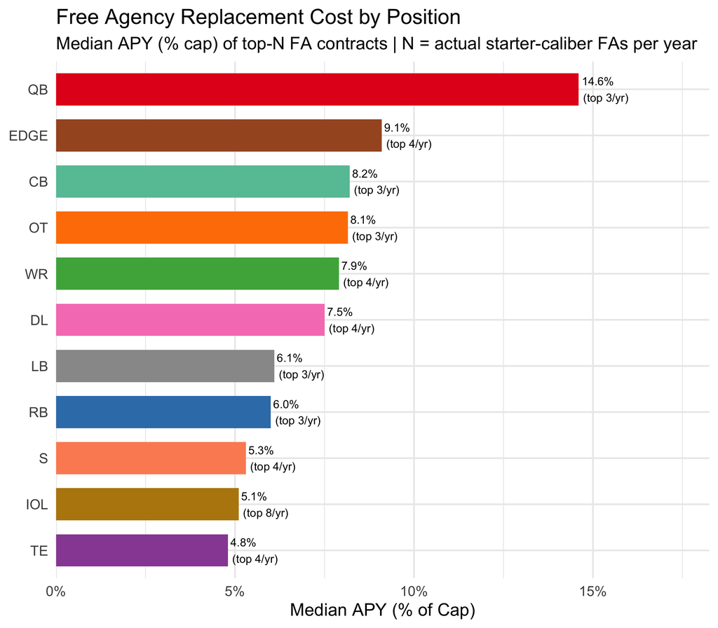

For context, the chart above uses all available contract years to get stable estimates. But the FA market has shifted recently — here’s what the same numbers look like using only 2020+ contracts:

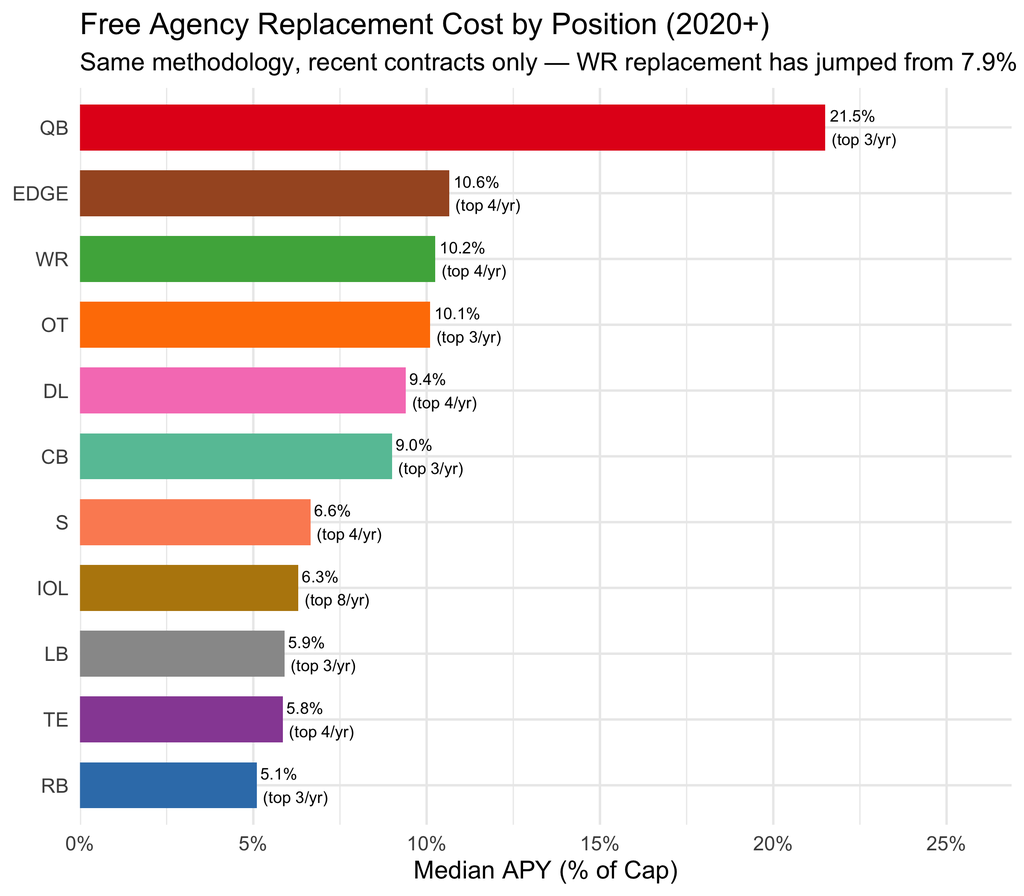

## The Formula

There are two metrics borne out of this analysis: a supply-controlled **player return value** and a position-controlled **Sharpe ratio** we can use to evaluate the risk-adjusted return of taking different positions at different points in the NFL draft.

The return on a draft pick comes from two sources:

**1. Rookie Contract Surplus** — You get starter-level production at a fraction of market cost.

$$\text{Rookie Surplus} = \text{Snap
Ratio} \times (\text{FA Replacement Cost} - \text{Rookie Salary}) \times
4 \text{ years}$$

**2. Second Contract** — The market’s verdict on whether the player was worth it.

$$\text{Player Return} = \text{Second
Contract Cap\%} + \text{Rookie Surplus}$$

Then the Sharpe ratio measures risk-adjusted return above the free-agency alternative:

$$\text{Sharpe} = \frac{P(\text{elite})
\times \text{Elite Threshold} - \text{FA Replacement
Cost}}{SD(\text{Player Return})}$$

| Component | What it measures | How it’s computed |
| --- | --- | --- |
| **Snap Ratio** | Playing time vs positional baseline | avg snap % / hit threshold (1.0 = starter) |
| **Rookie Surplus** | Cap savings during rookie deal | snap_ratio x (FA cost - rookie salary) x 4 years |
| **Second Contract** | Market value after rookie deal | APY as % of salary cap on next deal |
| **Player Return** | Total value of the pick | second contract + rookie surplus |
| **Elite Threshold** | Top-tier outcome bar | 90th percentile of all player returns |
| **FA Replacement** | Cost of buying a starter instead | Median of top-N FA contracts/yr; N = avg number of starter-caliber FAs per position per year (calibrated to Riske hit earnings) |
| **Volatility** | Outcome variance in that bucket | Std dev of player returns (including busts at $0) |

### Player Examples: How the Formula Works

Before looking at aggregate results, let’s see how the formula plays out for three real top-10 picks — one QB, one WR, and one RB.

Josh Allen — Pick #7, 2018

| Metric | Value | Calculation |
| --- | --- | --- |
| Avg snap % | 92.1% | Averaged over first 4 NFL seasons (missed games = 0%) |
| Snap ratio | 1.48× | 92.1% / hit threshold = 1.48× (≥1.0 = hit) |
| Rookie deal APY | 3.0% | Cost of his rookie contract as % of cap |
| FA median (QB) | 14.6% | What a starting QB costs in free agency |
| Rookie surplus | 68.7% | 1.48× × (14.6% − 3.0%) × 4 yrs = 68.7% |
| Second contract APY | 23.6% | His second deal as % of cap |
| Player return | 92.3% | 68.7% + 23.6% = 92.3% |
| Elite threshold | 33.1% | Top 10% of all player returns across all positions |

D.J. Moore — Pick #24, 2018

| Metric | Value | Calculation |
| --- | --- | --- |
| Avg snap % | 75.1% | Averaged over first 4 NFL seasons (missed games = 0%) |
| Snap ratio | 1.17× | 75.1% / hit threshold = 1.17× (≥1.0 = hit) |
| Rookie deal APY | 1.6% | Cost of his rookie contract as % of cap |
| FA median (WR) | 7.9% | What a starting WR costs in free agency |
| Rookie surplus | 29.6% | 1.17× × (7.9% − 1.6%) × 4 yrs = 29.6% |
| Second contract APY | 10.8% | His second deal as % of cap |
| Player return | 40.4% | 29.6% + 10.8% = 40.4% |
| Elite threshold | 33.1% | Top 10% of all player returns across all positions |

Saquon Barkley — Pick #2, 2018

| Metric | Value | Calculation |
| --- | --- | --- |
| Avg snap % | 48.0% | Averaged over first 4 NFL seasons (missed games = 0%) |
| Snap ratio | 1.14× | 48.0% / hit threshold = 1.14× (≥1.0 = hit) |
| Rookie deal APY | 4.4% | Cost of his rookie contract as % of cap |
| FA median (RB) | 6.0% | What a starting RB costs in free agency |
| Rookie surplus | 7.3% | 1.14× × (6.0% − 4.4%) × 4 yrs = 7.3% |
| Second contract APY | 4.9% | His second deal as % of cap |
| Player return | 12.2% | 7.3% + 4.9% = 12.2% |
| Elite threshold | 33.1% | Top 10% of all player returns across all positions |

All three players were drafted in 2018. Josh Allen’s player return (92.3%) clears the elite threshold (33.1%) comfortably. Massive rookie surplus from getting a franchise QB at a rookie wage, plus a huge second contract. D.J. Moore (40.4%) was a late first-round pick who earned a solid second contract, drafted 22 picks later than Saquon at a fraction of the draft capital cost. Saquon *was* a hit — he started, he produced, he earned a second contract. But his total return (12.2%) is well below the elite threshold. That’s because RB second contracts are small. Saquon’s 4.9% of cap is a fraction of what a QB or WR earns. His rookie surplus (7.3%) does the heavy lifting, but it’s not enough to reach elite territory.

### Worked Example: Aggregating to the Bucket Level

The player examples above show how the formula works for individuals. But to evaluate whether a *position* is worth a top-10 pick, we need to aggregate all the players in that bucket. When we look at every QB, WR, and RB drafted in the top 10 since 2010, we can calculate what percentage produced elite returns, how much variance there is, and whether the expected payoff beats the free-agency alternative.

Walking through the Sharpe formula with real numbers for every top-10 pick at each position:

| Step | What it means | QB Top 10 | WR Top 10 | RB Top 10 | Calculation |
| --- | --- | --- | --- | --- | --- |
| **P(elite)** | % of picks producing an elite player return | 73.1% | 25.0% | 0.0% | How often a top-10 pick at this position cracks the top 10% of *all* player returns |
| **Elite Threshold** | The top-10% return bar | 33.1% | 33.1% | 33.1% | 90th percentile of all player returns (rookie surplus + 2nd contract) |
| **P(elite) × Threshold** | Expected payoff | 24.2% | 8.3% | 0.0% | QB: 73.1% × 33.1% = 24.2% |
| **FA Replacement** | Cost to sign a starter instead | 14.6% | 7.9% | 6.0% | Median of top-N FA contracts by position |
| **Numerator** | Expected value over replacement | 9.6% | 0.4% | -6.0% | QB: 24.2% − 14.6% = 9.6% |
| **SD (volatility)** | How much do outcomes vary? | 25.7% | 10.7% | 9.7% | Std dev of all player returns in this bucket |
| **Sharpe** | Risk-adjusted return | **0.37** | **0.04** | **-0.62** | QB: 9.6% / 25.7% = 0.37 |

**QB Top 10:** 73.1% of top-10 QBs produce elite returns, and FA QBs are expensive (14.6% of cap), but the expected elite payoff (24.2%) still exceeds the FA cost, so the numerator is positive. Even with high variance, the Sharpe is +0.37.

**WR Top 10:** 25.0% of top-10 WRs produce elite returns. The FA replacement cost is 7.9% of cap. The Sharpe lands at 0.04.

**RB Top 10:** 0.0% of top-10 RBs produced an elite return. Remember, the elite threshold (33.1%) is the 90th percentile of *all* player returns across every position. That’s the bar for a player whose combined rookie surplus and second-contract value puts them in the top 10% of all drafted players since 2010. Not a single top-10 RB cleared it. So the expected elite payoff is zero, but you’re still paying 6.0% in FA opportunity cost. The numerator goes negative, giving a Sharpe of -0.62. The math says: just sign a free agent.

## RB in the Top 10

Now that we have the tools, let’s come back to the question that started this: should a team Love Love at #4?

What does -0.62 look like in practice? Here are all 7 RBs drafted in the top 10 since 2010:

| Player | Pick | Year | Hit? | Player Return<sup>1</sup> |
| --- | --- | --- | --- | --- |
| Todd Gurley | #10 | 2015 | Yes | 31.3% |
| Christian McCaffrey | #8 | 2017 | Yes | 28.9% |
| Ezekiel Elliott | #4 | 2016 | Yes | 21.6% |
| Leonard Fournette | #4 | 2017 | Yes | 13.0% |
| Saquon Barkley | #2 | 2018 | Yes | 12.2% |
| C.J. Spiller | #9 | 2010 | No | 9.4% |
| Trent Richardson | #3 | 2012 | No | 6.6% |

<sup>1</sup> Elite threshold: 33.1% | None of these players reached it.

Five of seven became starters and the hit rate (71%) is solid. But **zero produced an elite return on the top-10 draft capital investment**. The highest return belongs to Todd Gurley at 31.3%, followed by Christian McCaffrey at 28.9%, both short of the 33.1% elite threshold.

**Why rookie surplus matters:** For most players with positive returns, the rookie contract accounts for **77–95% of the total return** (interquartile range). When you draft a player who starts, you’re getting production at a fraction of what it costs in free agency — and that gap, multiplied by 4 years, adds up.

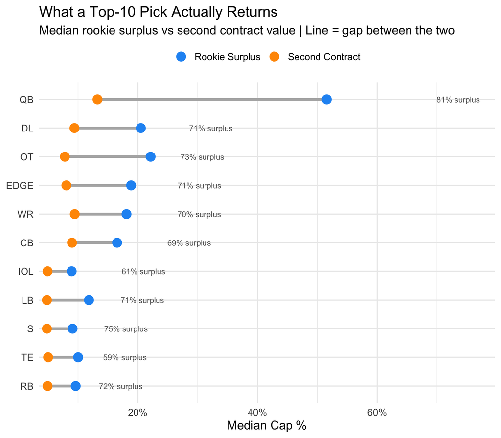

### What Teams Left on the Table

The Sharpe ratio flags specific position-tier combinations as negative. In other words, draft decisions the model says teams shouldn’t make. But what actually happened when teams made those picks? Instead of a theoretical counterfactual, we tracked the real one: for each negative-Sharpe first-round pick, we found the actual next QB, EDGE, OT, or WR drafted in the same year and compared surplus outcomes.

**Negative-Sharpe First-Round Picks (2010-2022)**

127 picks at negative-Sharpe combos vs the actual next QB/EDGE/OT/WR drafted

| Position | Picks | Avg Pick | What They Got Surplus ($M) | What They Got Hit % | Next Premium Player Taken Surplus ($M) | Next Premium Player Taken Hit % | Surplus Δ ($M) |  |
| --- | --- | --- | --- | --- | --- | --- | --- | --- |
| IOL | 33 | 17.5 | 44.5 | 54.5 | 82.6 | 42.4 |  | -38.1 |
| LB | 27 | 18.0 | 49.0 | 37.0 | 79.5 | 44.4 | -30.5 |  |
| S | 19 | 17.9 | 48.0 | 52.6 | 81.7 | 15.8 | -33.7 |  |
| RB | 16 | 16.0 | 48.1 | 56.2 | 92.3 | 50.0 | -44.2 |  |
| CB | 15 | 6.7 | 59.8 | 53.3 | 91.9 | 80.0 | -32.1 |  |
| TE | 10 | 18.0 | 41.2 | 60.0 | 85.7 | 50.0 | -44.5 |  |

Since 2010, **134 first-round picks** went to position-tier combos where the Sharpe ratio was negative. For **127** of those, we found the actual next premium-position player (QB, EDGE, OT, or WR) taken in the same draft. Those negative-Sharpe picks averaged **$49.2M** in surplus value. The next premium player taken averaged **$83M** in surplus — a gap of **-$33.8M**.

**RB specifically:** 16 first-round RBs at negative-Sharpe tiers, averaging **$48.1M** in surplus vs **$92.3M** for the next premium player actually drafted (Δ = **-$44.2M**). The surplus gap is the dagger — it’s the value teams left on the table by taking a running back instead of the next QB, EDGE, OT, or WR.

Why are these numbers so large? Surplus value is driven by the gap between a rookie contract and free-agent replacement cost, compounded over four years. Consider the 2021 draft: Kyle Pitts (pick 4, TE) earned ~4.2% of the cap on his rookie deal, while a replacement TE costs ~5%, a savings of roughly $2–3M/yr, or about **$8–12M over four years**. Ja’Marr Chase (pick 5, WR) earned ~4.1%, but a replacement WR costs ~10%, a savings of roughly $15M/yr, or about **$60M over four years**. Both were legitimate hits on the field, but Chase’s four-year rookie surplus dwarfs Pitts’ purely because WR has a more expensive free-agent market than TE. Same draft, adjacent picks, similar production profiles early on, wildly different surplus value, because the cost-controlled advantage at a premium position is structurally larger.

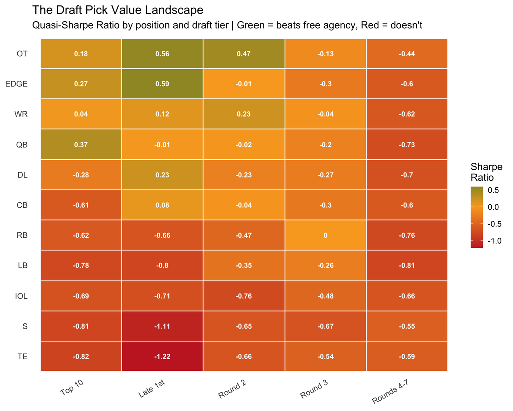

This is the whole story in one chart. Green cells are where the draft beats free agency; red cells are where it doesn’t. Most of the green is in the late first and Round 2 (not the top 10). The rest of this analysis explains why.

## Sharpe Ratio Curves

How does the Sharpe ratio decay as you move to later tiers? QB separates immediately. OT and EDGE peak in the late first round instead of the top 10.

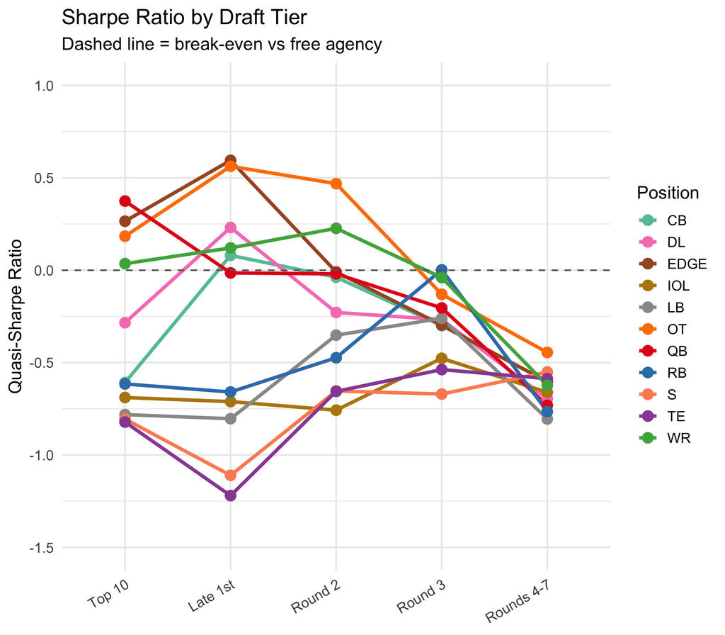

## Is a WR2 Worth More Than an Elite RB1?

To further drive this point home, let’s take a look at a recent signing. Rashid Shaheed, a WR3, just signed for **$17M per year** and was a spark in the Seahawks offense and return game during their Super Bowl run, but by no means is considered one of the top WRs in the league. Only 2 running backs in the entire league earn more (Saquon Barkley and Christian McCaffrey). The WR market is roughly **double** the RB market at the top end.

The Sharpe ratio helps explain this dynamic, and this somewhat confusing contract comparison should be a little more reasonable given what we know about opportunity cost, supply, and demand of the free agent market.

**RB Top 10 Sharpe: -0.62** vs **WR Round 2 Sharpe: 0.23**

In this framework, a Round 2 WR looks like a substantially better risk-adjusted investment than a top-10 RB, though this model measures contract value, not on-field impact, a distinction that matters most for running backs.

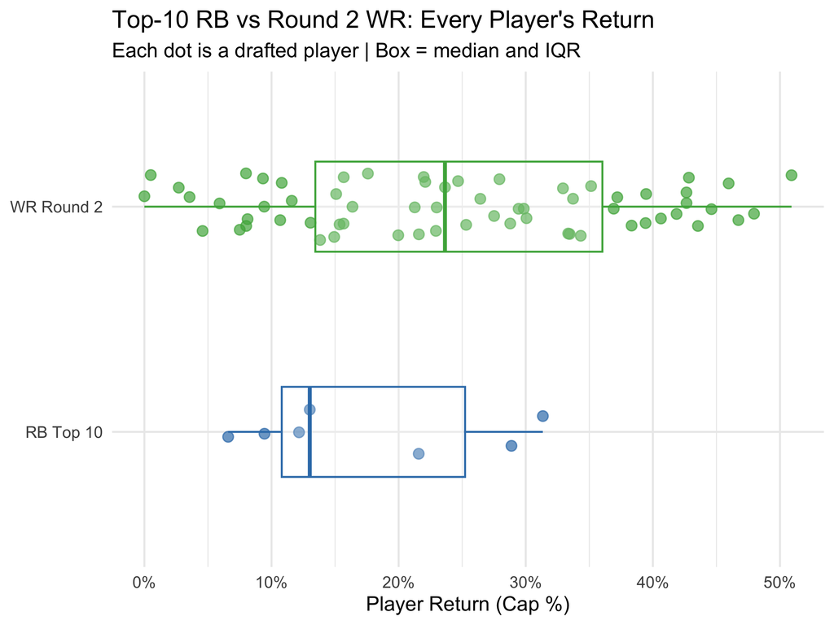

## Where Does Draft Capital Matter Most?

If you do not have a quarterback, you need to be taking as many shots at the position in the top 10 until you hit. Easier said than done, but the math is clear. EDGE, OT, and WR are also positive Sharpe picks in the top 10 and actually get *better* as you move later into the first round, suggesting that trading back is a viable strategy: you get even more of a rookie discount for these premium positions with similar upside.

### Premium pick justified

QB has the highest top-10 Sharpe (0.37). The rookie surplus is large (FA replacement is 14.6% of cap) and second-contract ceilings are the highest in football. A caveat: projecting QB talent is notoriously unreliable. The Sharpe reflects the *average* payoff. It says the math favors QB, not that the scouting is easy.

### Good early, even better late

Other positions with positive Sharpe values see their Sharpe grow as you move from the early to late first round. Trading down could improve expected value, but it comes with real risk: someone else takes your target, and the player you wanted at 8 isn’t there at 20.

- **EDGE**: Top 10 = 0.27 → Late 1st = 0.59. The late-first EDGE rushers benefit from landing on better teams with more established supporting casts, and the hit rate stays strong enough to produce elite outcomes.
- **OT**: Top 10 = 0.18 → Late 1st = 0.56. OT peaks in the late first, likely because the position rewards polish and technique that develops in college more than raw athleticism, so later OTs are more NFL-ready relative to their draft cost.
- **WR**: Top 10 = 0.04 → Late 1st = 0.12. WR talent is deep enough that Round 2 picks (Sharpe: 0.23 ) are competitive with the late first. Names like DK Metcalf and Davante Adams came from this range.

### Efficient Draft Allocation by Round

The following chart shows a round-adjusted Sharpe value that identifies where teams should be allocating their draft capital efficiently. It measures each position’s Sharpe *relative to the round average*, controlling for the fact that later rounds naturally have lower absolute Sharpe.

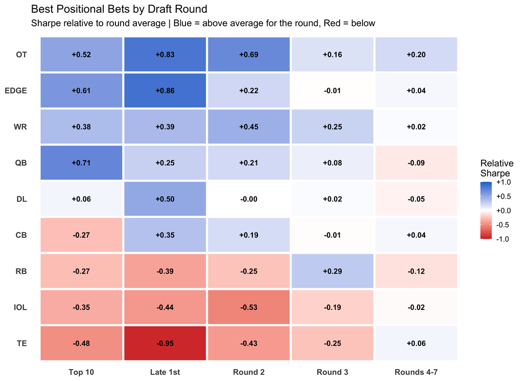

**In Round 1**, QB, EDGE, and OT are significantly above the round average (these are the positions where early draft capital pays off). Meanwhile, positions like TE and IOL are the worst relative bets in the first round.

**The later rounds flip the script.** By Round 3, the best relative position is actually **RB** (+0.29 above round average). This doesn’t mean Round 3 RBs produce elite returns (the absolute Sharpe is still low), but it means if you’re going to draft an RB, Round 3 is where the risk-reward ratio is the most favorable. Similarly, OT remains an above-average bet deep into the draft.

**The takeaway for GMs:** it’s not just about which positions to draft, it’s about *when*. The same position can be a great bet in one round and a terrible one in another.

There are pockets of the draft where it makes sense to take non-premium positions. Eventually the opportunity cost flips to a point where DL and CB become positive risk-adjusted bets.

- **DL**: Top 10 = -0.28 → Late 1st = 0.23. Interior defensive linemen develop well outside the top 10, and the FA market provides a reasonable alternative.
- **CB**: Top 10 = -0.61 → Late 1st = 0.08. CB is a boom-or-bust position in the top 10, but the late first and Round 2 produce strong starters at a fraction of the capital cost.

### Round 1: Where Opportunity Cost Is Highest

Round 1 is where the opportunity cost is highest. Teams can absolutely take bets on non-premium positions here based on need, but the Sharpe ratio, as we’ve shown, suggests these are negative expected-value bets. Breaking against the Sharpe means you have high confidence in a player hitting at the upper end of their potential and thus overcoming the opportunity cost. And of course, premium-position picks can bust too. We are trying to maximize expected value over many picks in many drafts so we come out ahead in the long run. At least that’s what teams *should* be doing.

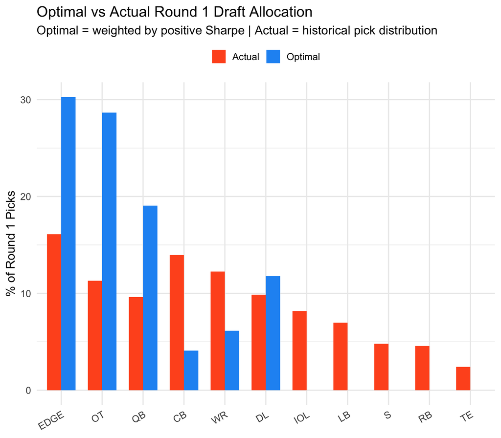

## Team-Level Draft Efficiency

Which teams have drafted most optimally? I score each team’s Round 1 picks by comparing what they actually drafted to what the Sharpe data says they should have, focusing on the last 5 eligible draft classes (2018–2022). Recent enough to reflect current front office philosophy, but far enough back that every player has had time for a second contract.

*Note: Not all teams had draft picks in every round during this window. The Rams are the extreme example, making zero first-round picks between 2018 and 2022 after trading them away in deals for Jalen Ramsey and Matthew Stafford. Teams with fewer picks in a given round may appear higher or lower than expected due to small sample size.*

[figure not shown]

[figure not shown]

[figure not shown]

[figure not shown]

**The spread is enormous.** PHI averages +0.24 per first-round pick while PIT sits at -0.64. Over 5 draft classes, that’s not randomness. It’s positional philosophy. Teams at the top are investing Round 1 capital in QB, EDGE, and OT, the positions where the Sharpe ratio is actually positive. Teams at the bottom are spending premium picks on positions where the data says free agency is a better path.

**In the later rounds**, the chart shifts to *relative* Sharpe, measuring how well each team targets the best-available positions for that round. Since almost every position has negative absolute Sharpe after Round 1, what matters is whether you’re picking the positions that are above or below the round average. A team above zero isn’t necessarily finding elite talent. They’re making the best of the capital they have.